[figure not shown]

AFRICAST

Tidy time series & forecasting in R

# Transformations, decompositions and features

[figure not shown]

[figure not shown]

[figure not shown]

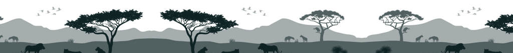

workshop.f4sg.org/africastForecasting for Social Good

## Outline

- Transforming time series
- Adjusting time series
- Time series decompositions
- STL Features
- Clustering features

# Transforming time series

## Variance stabilisation

If the data show different variation at different levels of the series, then a transformation can be useful.

Denote original observations as $y_1,\dots,y_n$ and transformed observations as $w_1, \dots, w_n$.

**Mathematical transformations for stabilising variation**

$$\begin{array}{llc}
\text{Square root} & w_t = \sqrt{y_t} & \downarrow \\
\text{Cube root} & w_t = \sqrt[3]{y_t} & \text{Increasing} \\
\text{Logarithm} & w_t = \text{log}(y_t) & \text{strength}
\end{array}$$

Logarithms, in particular, are useful because they are more interpretable: changes in a log value are **relative (percent) changes on the original scale**.

## Variance stabilisation

```r
food <- aus_retail |>
  filter(Industry == "Food retailing") |>
  summarise(Turnover = sum(Turnover))
```

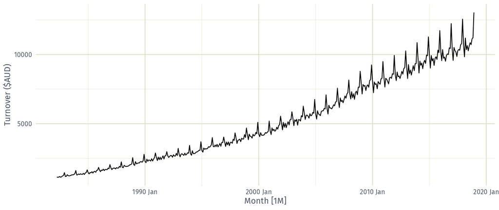

## Variance stabilisation

```r
food |> autoplot(sqrt(Turnover)) +
  labs(y = "Square root turnover")
```

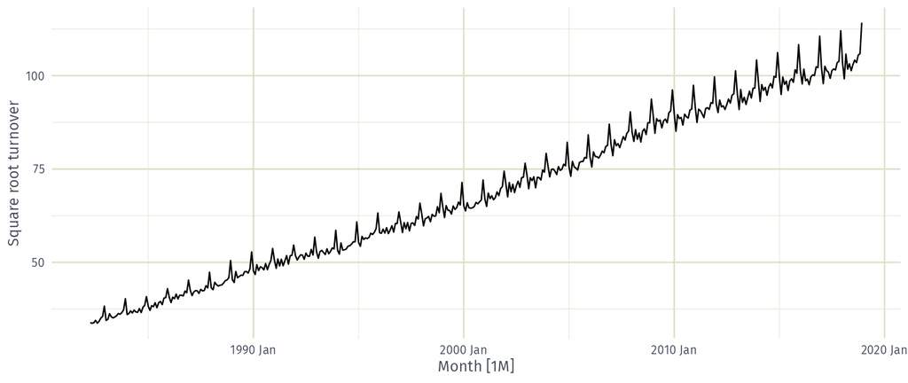

## Variance stabilisation

```r
food |> autoplot(Turnover^(1 / 3)) +
  labs(y = "Cube root turnover")
```

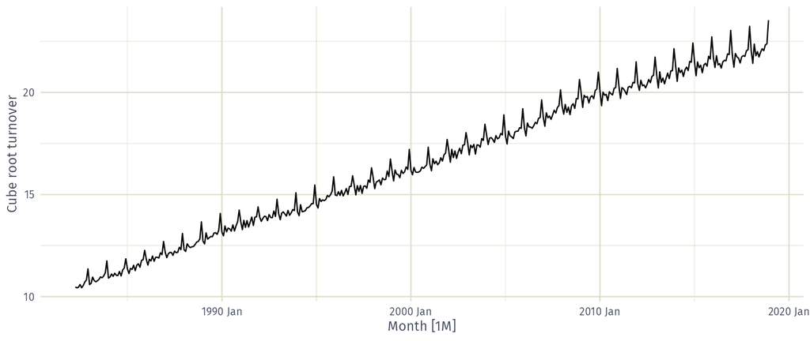

## Variance stabilisation

```r
food |> autoplot(log(Turnover)) +
  labs(y = "Log turnover")
```

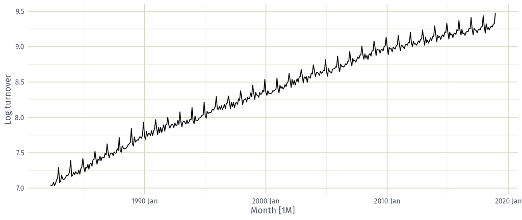

## Variance stabilisation

```r
food |> autoplot(-1 / Turnover) +
  labs(y = "Negative inverse turnover")
```

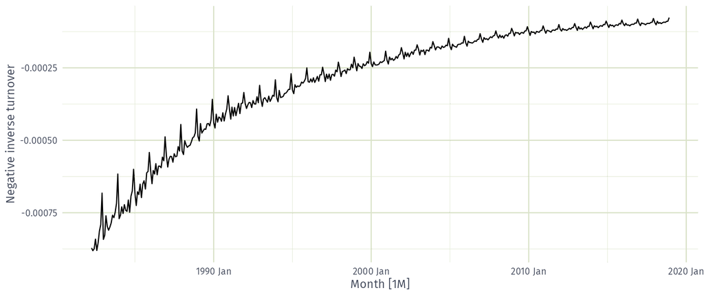

## Variance stabilisation

Which transformation best stabilises the variance of food turnover?

- Square root
- Cube root
- Logarithm
- Inverse

## Box-Cox transformations

Each of these transformations is close to a member of the family of **Box-Cox transformations**:
$$w_t = \left\{\begin{array}{ll}
\text{log}(y_t), & \quad \lambda = 0; \\
(\text{sign}(y_t)|y_t|^\lambda-1)/\lambda , & \quad \lambda \ne 0.
\end{array}\right.$$

- Actually the Bickel-Doksum transformation (allowing for $y_t<0$)
- $\lambda=1$: (No substantive transformation)
- $\lambda=\frac12$: (Square root plus linear transformation)
- $\lambda=0$: (Natural logarithm)
- $\lambda=-1$: (Negative inverse plus 1)

## Box-Cox transformations

## Box-Cox transformations

What is the best value of λ for food retailing turnover?

*Scale: 0–0.1 · 0.1–0.2 · 0.2–0.3 · 0.3–0.4 · 0.4–0.5 · 0.5–0.6 · 0.6–0.7 · 0.7–0.8 · 0.8–0.9 · 0.9–1.0*

## Box-Cox transformations

```r
food |>
  features(Turnover, features = guerrero)
```

```
# A tibble: 1 × 1
  lambda_guerrero
            <dbl>
1          0.0895
```

- This attempts to balance the seasonal fluctuations and random variation across the series.
- Always check the results.
- A low value of $\lambda$ can give extremely large prediction intervals.

## Box-Cox transformations

```r
food |> autoplot(box_cox(Turnover, 0.0895)) +
  labs(y = "Box-Cox transformed turnover")
```

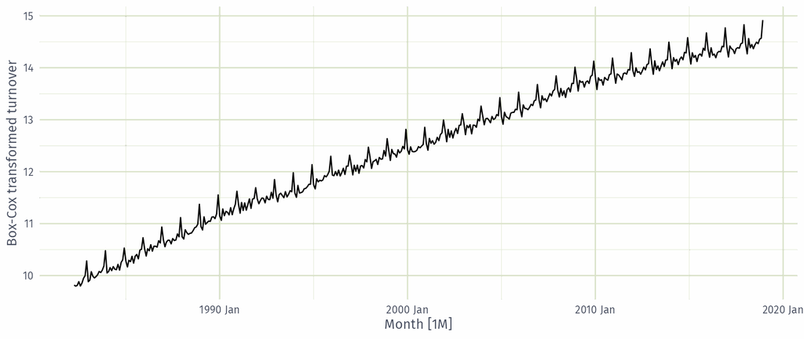

## Transformations

- Often no transformation needed.
- Simple transformations are easier to explain and work well enough.
- Transformations can have very large effect on PI.
- If some data are zero or negative, then use $\lambda>0$.
- `log1p()` can also be useful for data with zeros.
- Choosing logs is a simple way to force forecasts to be positive
- Transformations must be reversed to obtain forecasts on the original scale. (Handled automatically by `fable`.)

# Adjusting time series

## Per capita adjustments

```r
global_economy |>
  filter(Country == "Australia") |>
  autoplot(GDP)
```

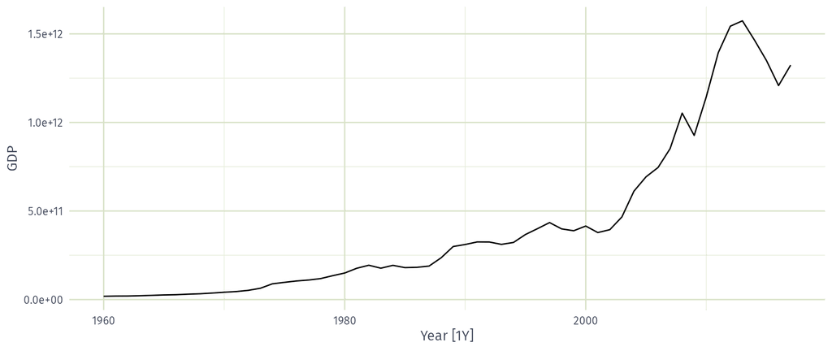

## Per capita adjustments

```r
global_economy |>
  filter(Country == "Australia") |>
  autoplot(GDP / Population)
```

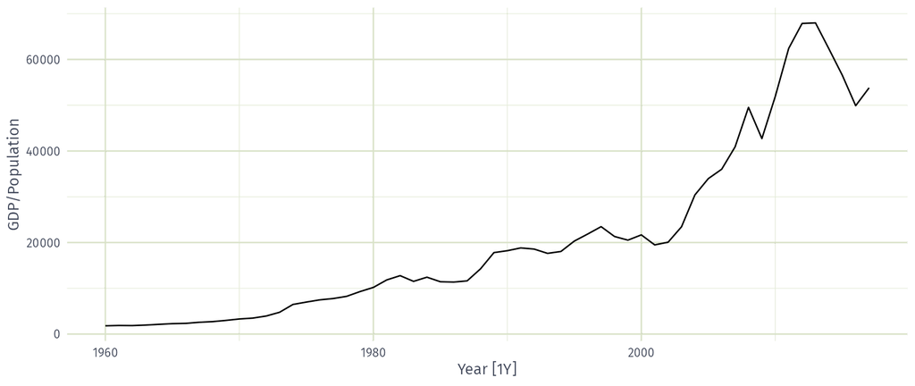

## Inflation adjustments

```r
print_retail <- aus_retail |>
  filter(Industry == "Newspaper and book retailing") |>
  group_by(Industry) |>
  index_by(Year = year(Month)) |>
  summarise(Turnover = sum(Turnover))
aus_economy <- filter(global_economy, Country == "Australia")
print_retail |>
  left_join(aus_economy, by = "Year") |>
  mutate(Adj_turnover = Turnover / CPI) |>
  pivot_longer(c(Turnover, Adj_turnover),
    names_to = "Type", values_to = "Turnover"
  ) |>
  ggplot(aes(x = Year, y = Turnover)) +
  geom_line() +
  facet_grid(vars(Type), scales = "free_y") +
  labs(x = "Years", y = NULL,
       title = "Turnover: Australian print media industry")
```

## Inflation adjustments

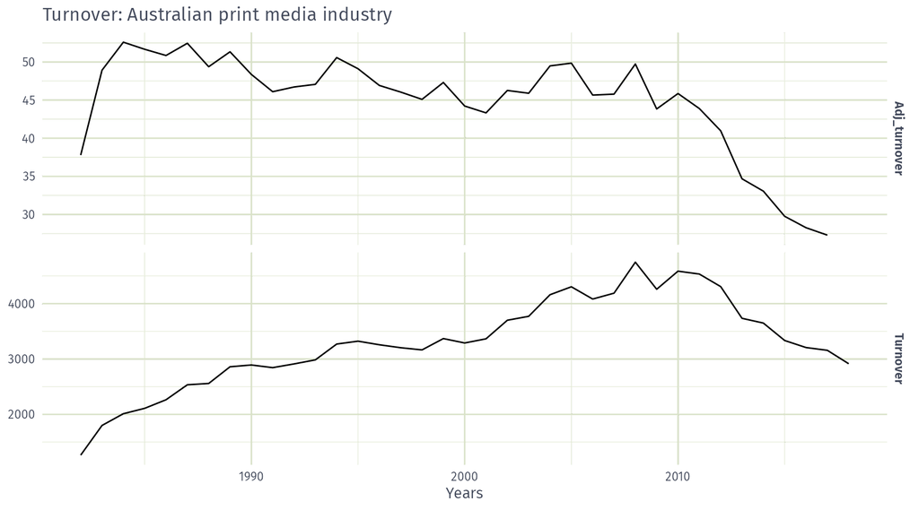

# Time series decompositions

## Time series decomposition

**Trend-Cycle**

aperiodic changes in level over time.

**Seasonal**

(almost) periodic changes in level due to seasonal factors (e.g., the quarter of the year, the month, or day of the week).

**Additive decomposition**

$$y_t = S_t + T_t + R_t$$

$$\begin{aligned}
\text{where}\quad & y_t = \text{ data at period } t \\
& T_t = \text{ trend-cycle component at period } t \\
& S_t = \text{ seasonal component at period } t \\
& R_t = \text{ remainder component at period } t
\end{aligned}$$

## STL decomposition

- STL: “Seasonal and Trend decomposition using Loess”
- Very versatile and robust.
- Seasonal component allowed to change over time, and rate of change controlled by user.
- Smoothness of trend-cycle also controlled by user.
- Optionally robust to outliers
- No trading day or calendar adjustments.
- Only additive.
- Take logs to get multiplicative decomposition.
- Use Box-Cox transformations to get other decompositions.

## US Retail Employment

```r
us_retail_employment <- us_employment |>
  filter(year(Month) >= 1990, Title == "Retail Trade") |>
  select(-Series_ID)
us_retail_employment
```

```
# A tsibble: 357 x 3 [1M]
      Month Title        Employed
      <mth> <chr>           <dbl>
 1 1990 Jan Retail Trade   13256.
 2 1990 Feb Retail Trade   12966.
 3 1990 Mar Retail Trade   12938.
 4 1990 Apr Retail Trade   13012.
 5 1990 May Retail Trade   13108.
 6 1990 Jun Retail Trade   13183.
 7 1990 Jul Retail Trade   13170.
 8 1990 Aug Retail Trade   13160.
 9 1990 Sep Retail Trade   13113.
10 1990 Oct Retail Trade   13185.
# ℹ 347 more rows
```

## US Retail Employment

```r
us_retail_employment |>
  autoplot(Employed) +
  labs(y = "Persons (thousands)", title = "Total employment in US retail")
```

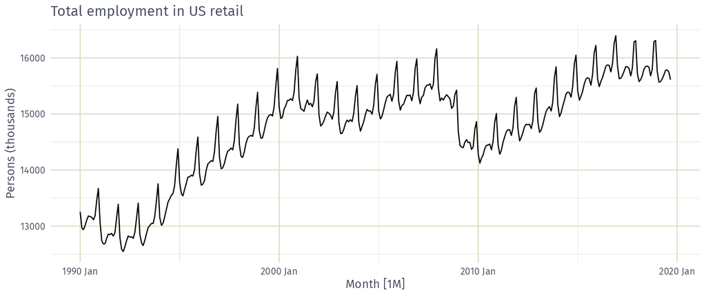

## US Retail Employment

```r
dcmp <- us_retail_employment |>
  model(stl = STL(Employed))
dcmp
```

```
# A mable: 1 x 1
      stl
  <model>
1   <STL>
```

## US Retail Employment

```r
components(dcmp)
```

```
# A dable: 357 x 7 [1M]
# Key:     .model [1]
# :        Employed = trend + season_year + remainder
   .model    Month Employed  trend season_year remainder season_adjust
   <chr>     <mth>    <dbl>  <dbl>       <dbl>     <dbl>         <dbl>
 1 stl    1990 Jan   13256. 13288.      -33.0      0.836        13289.
 2 stl    1990 Feb   12966. 13269.     -258.     -44.6          13224.
 3 stl    1990 Mar   12938. 13250.     -290.     -22.1          13228.
 4 stl    1990 Apr   13012. 13231.     -220.       1.05         13232.
 5 stl    1990 May   13108. 13211.     -114.      11.3          13223.
 6 stl    1990 Jun   13183. 13192.      -24.3     15.5          13207.
 7 stl    1990 Jul   13170. 13172.      -23.2     21.6          13193.
 8 stl    1990 Aug   13160. 13151.       -9.52    17.8          13169.
 9 stl    1990 Sep   13113. 13131.      -39.5     22.0          13153.
10 stl    1990 Oct   13185. 13110.       61.6     13.2          13124.
# ℹ 347 more rows
```

## US Retail Employment

```r
components(dcmp) |> autoplot()
```

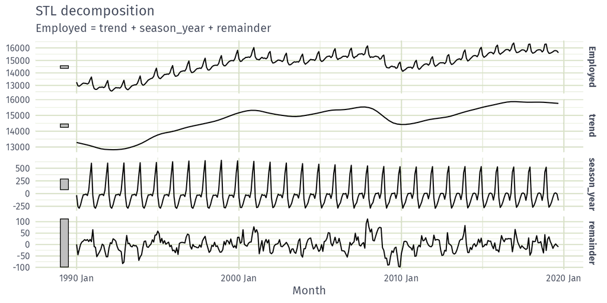

## US Retail Employment

```r
us_retail_employment |>
  autoplot(Employed, color = "gray") +
  autolayer(components(dcmp), trend, color = "#D55E00") +
  labs(y = "Persons (thousands)", title = "Total employment in US retail")
```

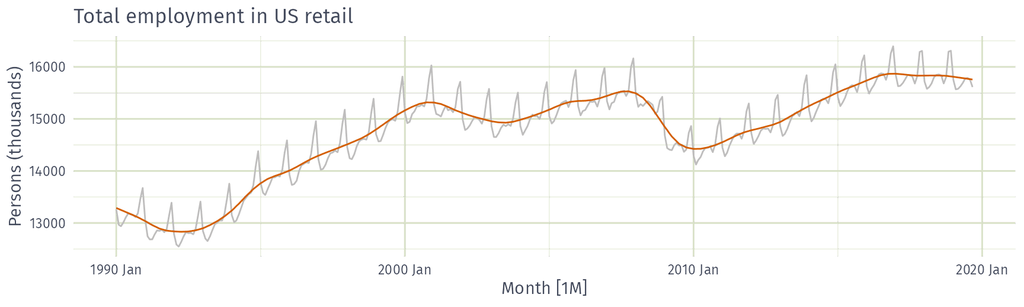

## US Retail Employment

```r
components(dcmp) |> gg_subseries(season_year)
```

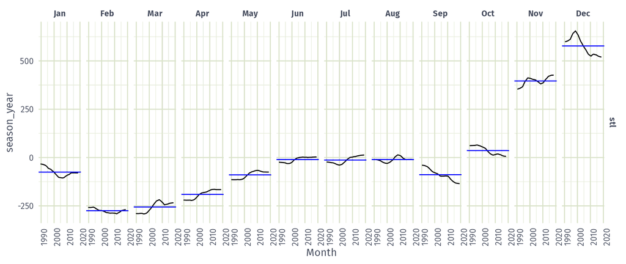

## Seasonal adjustment

- Useful by-product of decomposition: an easy way to calculate seasonally adjusted data.
- Additive decomposition: seasonally adjusted data given by
  $$y_t - S_t = T_t + R_t$$
- Multiplicative decomposition: seasonally adjusted data given by
  $$y_t / S_t = T_t \times R_t$$

## US Retail Employment

```r
us_retail_employment |>
  autoplot(Employed, color = "gray") +
  autolayer(components(dcmp), season_adjust, color = "#0072B2") +
  labs(y = "Persons (thousands)", title = "Total employment in US retail")
```

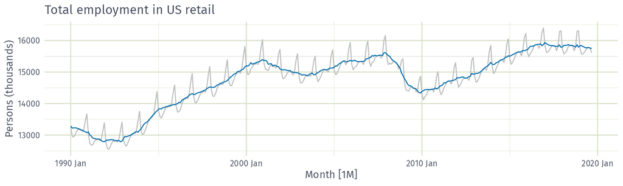

## Seasonal adjustment

- We use estimates of $S$ based on past values to seasonally adjust a current value.
- Seasonally adjusted series reflect **remainders** as well as **trend**. Therefore they are not “smooth” and “downturns” or “upturns” can be misleading.
- It is better to use the trend-cycle component to look for turning points.

## STL decomposition

## STL decomposition

```r
us_retail_employment |>
  model(STL(Employed ~ trend(window = 15) + season(window = "periodic"),
    robust = TRUE
  )) |>
  components()
```

- `trend(window = ?)` controls wiggliness of trend component.
- `season(window = ?)` controls variation on seasonal component.
- `season(window = 'periodic')` is equivalent to an infinite window.

## STL decomposition

```r
us_retail_employment |>
  model(STL(Employed)) |>
  components() |>
  autoplot()
```

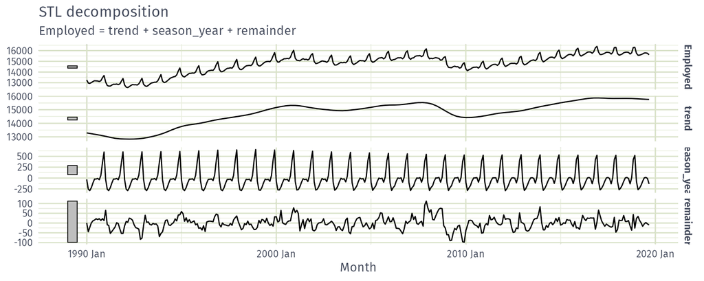

- `STL()` chooses `season(window=13)` by default
- Can include transformations.

## STL decomposition

- Algorithm that updates trend and seasonal components iteratively.
- Starts with $\hat{T}_t=0$
- Uses a mixture of loess and moving averages to successively refine the trend and seasonal estimates.
- trend window controls loess bandwidth on deseasonalised values.
- season window controls loess bandwidth on detrended subseries.
- Robustness weights based on remainder.
- Default season: `window = 13`
- Default trend: `window = nextodd(ceiling((1.5*period)/(1-(1.5/s.window))))`
- `window` values should be odd numbers for symmetry.

## Australian holidays

```r
holidays |> autoplot(Trips) +
  labs(y = "thousands of trips", x = "Year",
       title = "Australian domestic holiday trips")
```

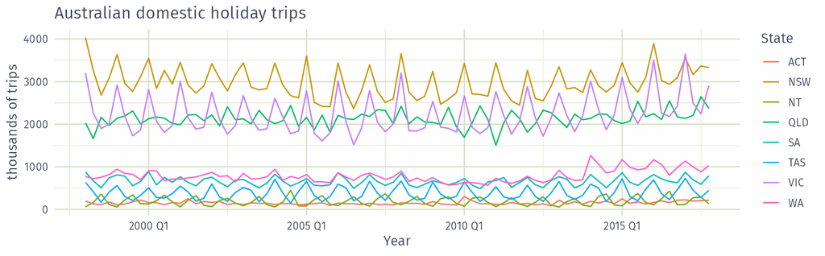

## Australian holidays

```r
holidays |>
  model(stl = STL(Trips)) |>
  components() |>
  autoplot()
```

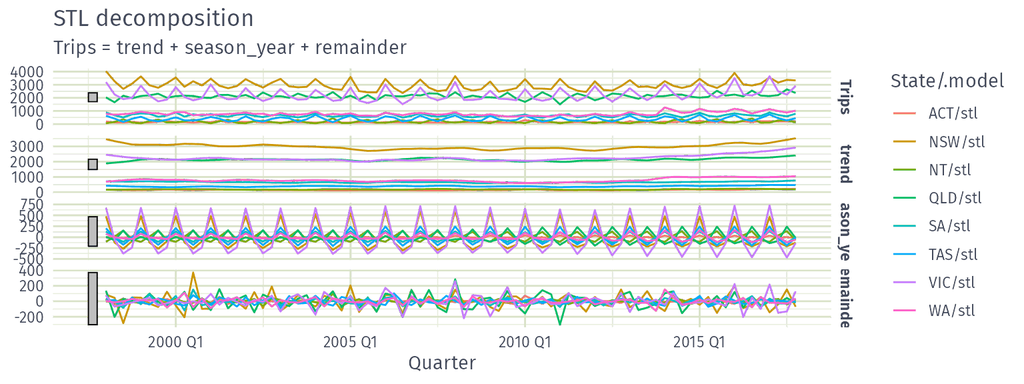

## Holidays decomposition

```r
dcmp <- holidays |>
  model(stl = STL(Trips)) |>
  components()
dcmp
```

```
# A dable: 640 x 8 [1Q]
# Key:     State, .model [8]
# :        Trips = trend + season_year + remainder
   State .model Quarter Trips trend season_year remainder season_adjust
   <chr> <chr>    <qtr> <dbl> <dbl>       <dbl>     <dbl>         <dbl>
 1 ACT   stl    1998 Q1  196.  172.       -8.48     32.6           205.
 2 ACT   stl    1998 Q2  127.  157.       10.3     -40.6           116.
 3 ACT   stl    1998 Q3  111.  142.      -16.8     -14.5           128.
 4 ACT   stl    1998 Q4  170.  130.       14.6      25.6           156.
 5 ACT   stl    1999 Q1  108.  135.       -8.63    -18.3           116.
 6 ACT   stl    1999 Q2  125.  148.       11.0     -34.6           114.
 7 ACT   stl    1999 Q3  178.  166.      -16.0      28.3           194.
 8 ACT   stl    1999 Q4  218.  177.       13.2      27.5           204.
 9 ACT   stl    2000 Q1  158.  169.       -8.75     -1.96          167.
10 ACT   stl    2000 Q2  155.  151.       11.7      -8.20          143.
# ℹ 630 more rows
```

## Holidays decomposition

```r
dcmp |> gg_subseries(season_year)
```

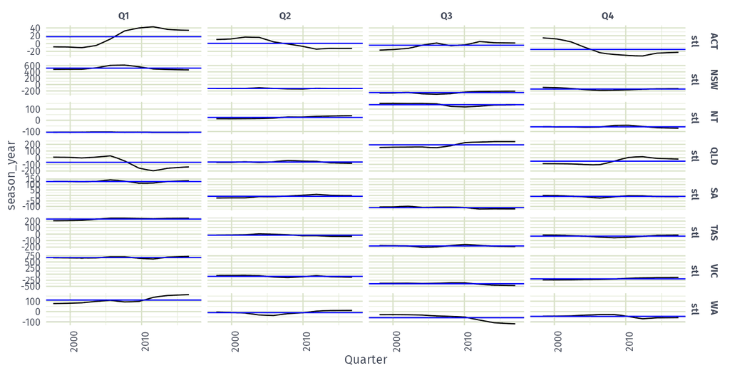

## Holidays decomposition

```r
autoplot(dcmp, trend, scale_bars = FALSE) +
  autolayer(holidays, alpha = 0.4)
```

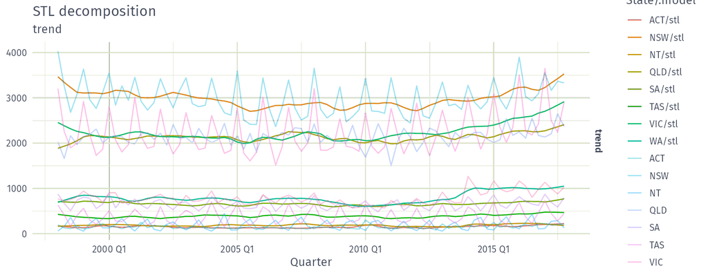

# STL Features

## Strength of seasonality and trend

**STL decomposition**

$y_t = T_t+S_t+R_t$

### Seasonal strength

$$\max\left(0, 1-\frac{\text{Var}(R_t)}{\text{Var}(S_t+R_t)}\right)$$

### Trend strength

$$\max\left(0, 1-\frac{\text{Var}(R_t)}{\text{Var}(T_t+R_t)}\right)$$

Both range from 0 (none) to 1 (strong), computed by `feat_stl()`.

## STL features

`tourism`: quarterly overnight trips (thousands) for 304 Australian domestic series, keyed by Region, State and Purpose.

```r
tourism |> features(Trips, feat_stl)
```

```
# A tibble: 304 × 12
   Region         State Purpose trend_strength seasonal_strength_year seasonal_peak_year
   <chr>          <chr> <chr>            <dbl>                  <dbl>              <dbl>
 1 Adelaide       SA    Busine…          0.464                  0.407                  3
 2 Adelaide       SA    Holiday          0.554                  0.619                  1
 3 Adelaide       SA    Other            0.746                  0.202                  2
 4 Adelaide       SA    Visiti…          0.435                  0.452                  1
 5 Adelaide Hills SA    Busine…          0.464                  0.179                  3
 6 Adelaide Hills SA    Holiday          0.528                  0.296                  2
 7 Adelaide Hills SA    Other            0.593                  0.404                  2
 8 Adelaide Hills SA    Visiti…          0.488                  0.254                  0
 9 Alice Springs  NT    Busine…          0.534                  0.251                  0
10 Alice Springs  NT    Holiday          0.381                  0.832                  3
# ℹ 294 more rows
# ℹ 6 more variables: seasonal_trough_year <dbl>, spikiness <dbl>, linearity <dbl>,
#   curvature <dbl>, stl_e_acf1 <dbl>, stl_e_acf10 <dbl>
```

## STL features

- `trend_strength`, `seasonal_strength_year`: strength of the trend and seasonal components.
- `seasonal_peak_year`, `seasonal_trough_year`: the quarter with the largest and smallest seasonal component.
- `spikiness`: prevalence of spikes in the remainder.
- `linearity`, `curvature`: shape of the trend, from a quadratic regression on time.
- `stl_e_acf1`: first autocorrelation of the remainder.
- `stl_e_acf10`: sum of squares of the first ten autocorrelations of the remainder.

## Seasonal and trend strength

```r
tourism |>
  features(Trips, feat_stl) |>
  ggplot(aes(x = trend_strength, y = seasonal_strength_year, col = Purpose)) +
  geom_point() + facet_wrap(vars(State))
```

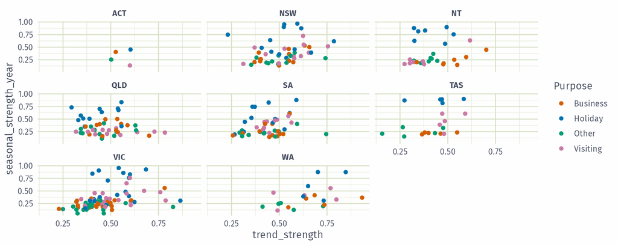

- Holidays more seasonal than other travel.
- WA series tend to have the strongest trends.

## Most seasonal series

Find the most seasonal time series:

```r
most_seasonal <- tourism |>
  features(Trips, feat_stl) |>
  filter(seasonal_strength_year == max(seasonal_strength_year))
```

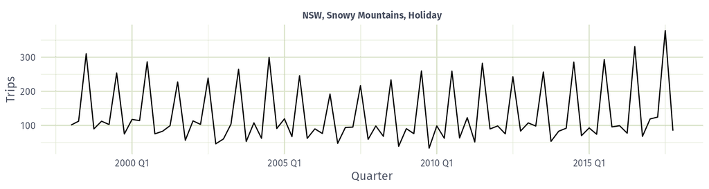

```r
tourism |>
  semi_join(most_seasonal, by = join_by(State, Region, Purpose)) |>
  ggplot(aes(x = Quarter, y = Trips)) +
  geom_line() +
  facet_wrap(vars(State, Region, Purpose), labeller = labeller(.multi_line = FALSE))
```

## Most trended series

Find the most trended time series:

```r
most_trended <- tourism |>
  features(Trips, feat_stl) |>
  filter(trend_strength == max(trend_strength))
```

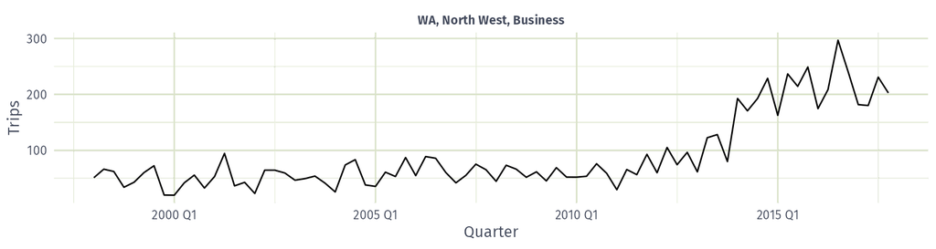

```r
tourism |>
  semi_join(most_trended, by = join_by(State, Region, Purpose)) |>
  ggplot(aes(x = Quarter, y = Trips)) +
  geom_line() +
  facet_wrap(vars(State, Region, Purpose), labeller = labeller(.multi_line = FALSE))
```

## ACF features

```r
tourism |> features(Trips, feat_acf)
```

```
# A tibble: 304 × 10
   Region     State Purpose     acf1 acf10 diff1_acf1 diff1_acf10 diff2_acf1 diff2_acf10
   <chr>      <chr> <chr>      <dbl> <dbl>      <dbl>       <dbl>      <dbl>       <dbl>
 1 Adelaide   SA    Busine…  0.0333  0.131     -0.520       0.463     -0.676       0.741
 2 Adelaide   SA    Holiday  0.0456  0.372     -0.343       0.614     -0.487       0.558
 3 Adelaide   SA    Other    0.517   1.15      -0.409       0.383     -0.675       0.792
 4 Adelaide   SA    Visiti…  0.0684  0.294     -0.394       0.452     -0.518       0.447
 5 Adelaide … SA    Busine…  0.0709  0.134     -0.580       0.415     -0.750       0.746
 6 Adelaide … SA    Holiday  0.131   0.313     -0.536       0.500     -0.716       0.906
 7 Adelaide … SA    Other    0.261   0.330     -0.253       0.317     -0.457       0.392
 8 Adelaide … SA    Visiti…  0.139   0.117     -0.472       0.239     -0.626       0.408
 9 Alice Spr… NT    Busine…  0.217   0.367     -0.500       0.381     -0.658       0.587
10 Alice Spr… NT    Holiday -0.00660 2.11      -0.153       2.11      -0.274       1.55
# ℹ 294 more rows
# ℹ 1 more variable: season_acf1 <dbl>
```

## ACF features

- `acf1`: first autocorrelation of the series.
- `acf10`: sum of squares of the first ten autocorrelations.
- `diff1_acf1`, `diff1_acf10`: the same, for the differenced series.
- `diff2_acf1`, `diff2_acf10`: the same, for the twice differenced series.
- `season_acf1`: autocorrelation at the first seasonal lag.

# Clustering features

## All feasts features

All features from the feasts package:

```r
tourism_features <- tourism |>
  features(Trips, feature_set(pkgs = "feasts"))
tourism_features
```

```
# A tibble: 304 × 51
   Region         State Purpose trend_strength seasonal_strength_year seasonal_peak_year
   <chr>          <chr> <chr>            <dbl>                  <dbl>              <dbl>
 1 Adelaide       SA    Busine…          0.464                  0.407                  3
 2 Adelaide       SA    Holiday          0.554                  0.619                  1
 3 Adelaide       SA    Other            0.746                  0.202                  2
 4 Adelaide       SA    Visiti…          0.435                  0.452                  1
 5 Adelaide Hills SA    Busine…          0.464                  0.179                  3
 6 Adelaide Hills SA    Holiday          0.528                  0.296                  2
 7 Adelaide Hills SA    Other            0.593                  0.404                  2
 8 Adelaide Hills SA    Visiti…          0.488                  0.254                  0
 9 Alice Springs  NT    Busine…          0.534                  0.251                  0
10 Alice Springs  NT    Holiday          0.381                  0.832                  3
# ℹ 294 more rows
# ℹ 45 more variables: seasonal_trough_year <dbl>, spikiness <dbl>, linearity <dbl>,
#   curvature <dbl>, stl_e_acf1 <dbl>, stl_e_acf10 <dbl>, acf1 <dbl>, acf10 <dbl>,
#   diff1_acf1 <dbl>, diff1_acf10 <dbl>, diff2_acf1 <dbl>, diff2_acf10 <dbl>,
#   season_acf1 <dbl>, pacf5 <dbl>, diff1_pacf5 <dbl>, diff2_pacf5 <dbl>,
#   season_pacf <dbl>, zero_run_mean <dbl>, nonzero_squared_cv <dbl>,
#   zero_start_prop <dbl>, zero_end_prop <dbl>, lambda_guerrero <dbl>, …
```

## Principal components

Principal components are combinations of the 48 features with the most variation, so the 304 series can be compared in two dimensions:

```r
pcs <- tourism_features |>
  select(-State, -Region, -Purpose) |>
  prcomp(scale. = TRUE) |>
  broom::augment(tourism_features)
pcs |> select(Region, State, Purpose, .fittedPC1, .fittedPC2)
```

```
# A tibble: 304 × 5
   Region         State Purpose  .fittedPC1 .fittedPC2
   <chr>          <chr> <chr>         <dbl>      <dbl>
 1 Adelaide       SA    Business     -0.868      1.25
 2 Adelaide       SA    Holiday       1.00       1.26
 3 Adelaide       SA    Other         4.90      -6.11
 4 Adelaide       SA    Visiting      0.306      1.48
 5 Adelaide Hills SA    Business     -5.00      -0.526
 6 Adelaide Hills SA    Holiday      -0.628     -1.42
 7 Adelaide Hills SA    Other        -0.256     -2.92
 8 Adelaide Hills SA    Visiting     -1.80      -2.18
 9 Alice Springs  NT    Business      1.07      -2.56
10 Alice Springs  NT    Holiday       4.36       7.31
# ℹ 294 more rows
```

## PC1 vs PC2

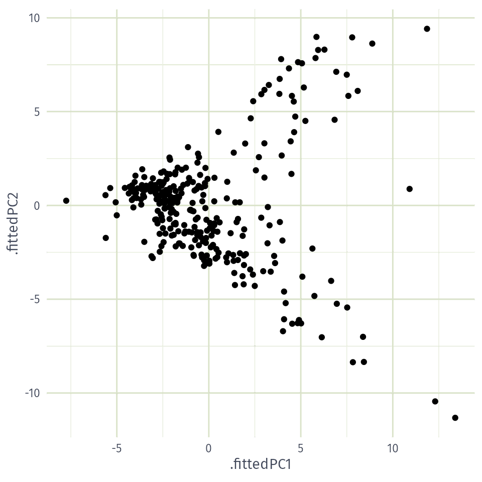

```r
pcs |>
  ggplot(aes(x = .fittedPC1, y = .fittedPC2)) +
  geom_point() +
  theme(aspect.ratio = 1)
```

## PCs coloured by State

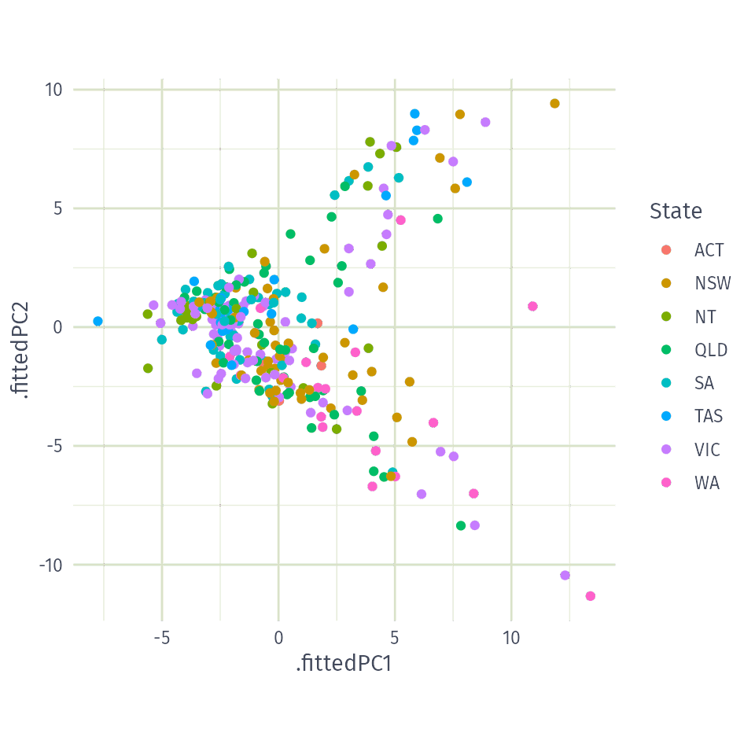

```r
pcs |>
  ggplot(aes(x = .fittedPC1, y = .fittedPC2,
             col = State)) +
  geom_point() +
  theme(aspect.ratio = 1)
```

## PCs coloured by Purpose

Holiday series sit higher on both PCs than other travel purposes.

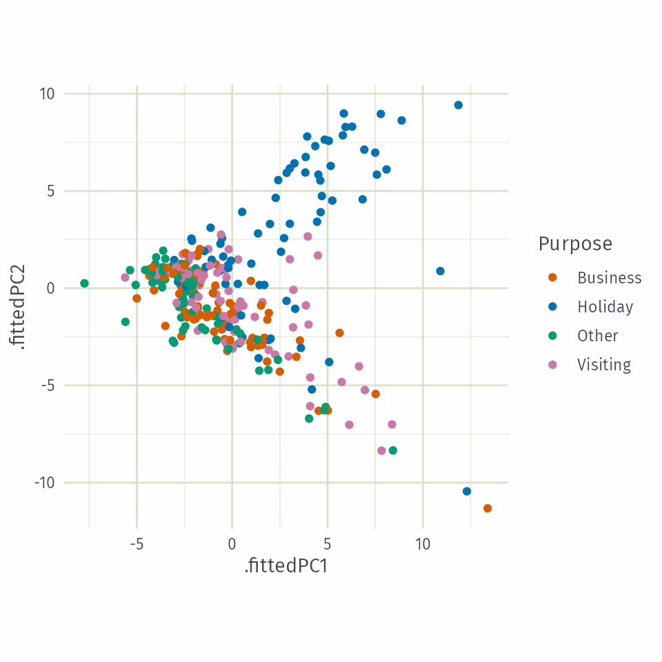

```r
pcs |>
  ggplot(aes(x = .fittedPC1, y = .fittedPC2,
             col = Purpose)) +
  geom_point() +
  theme(aspect.ratio = 1)
```

## Outliers in PC space

Four outlying series: PC1 > 12, or PC1 > 10 and PC2 > 0.

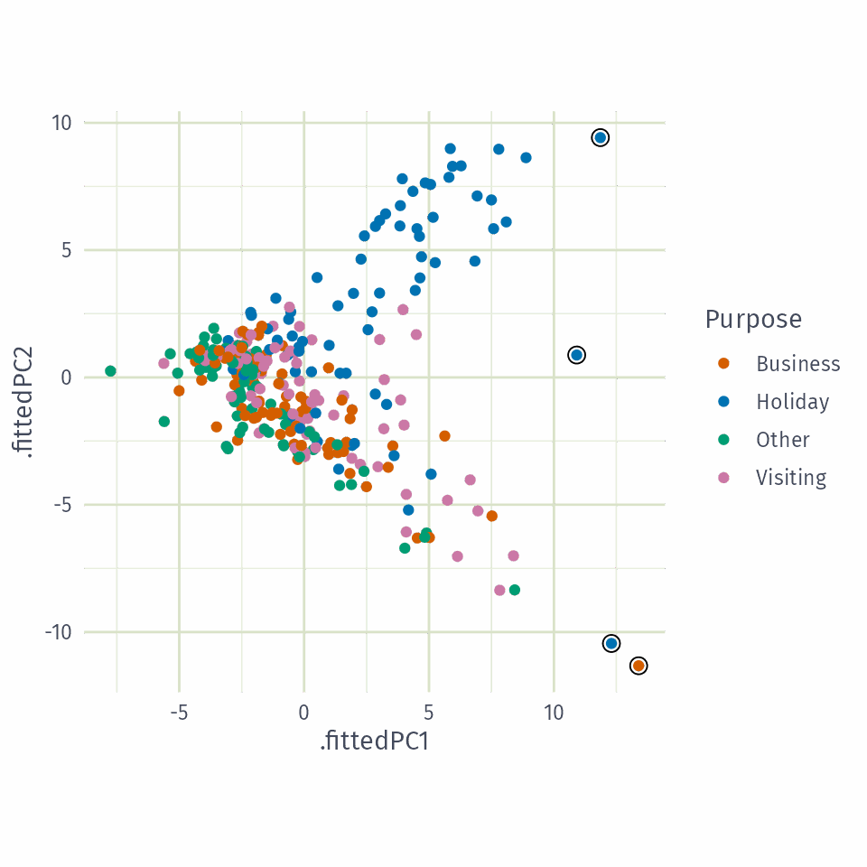

```r
outliers <- pcs |>
  filter(.fittedPC1 > 12 |
           (.fittedPC1 > 10 & .fittedPC2 > 0))
pcs |>
  ggplot(aes(x = .fittedPC1, y = .fittedPC2,
             col = Purpose)) +
  geom_point() +
  geom_point(data = outliers, col = "black",
             shape = 1, size = 3) +
  theme(aspect.ratio = 1)
```

## Outlying series

```r
tourism |>
  semi_join(outliers, by = join_by(State, Region, Purpose)) |>
  mutate(Series = glue("{State}", "{Region}", "{Purpose}", .sep = "\n\n")) |>
  ggplot(aes(x = Quarter, y = Trips)) +
  geom_line() + facet_grid(Series ~ .) +
  labs(title = "Outlying time series in PC space")
```

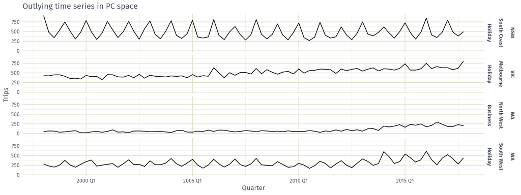